# Composition Analysis of the Polish National Bibliography dated 2025-10-31

# Overall summary

6,527,448 records and 479,315,579 attribute values in total. Constituent files:

- data/plnb/plnb.parquet (1.59GB)

## Temporal overview

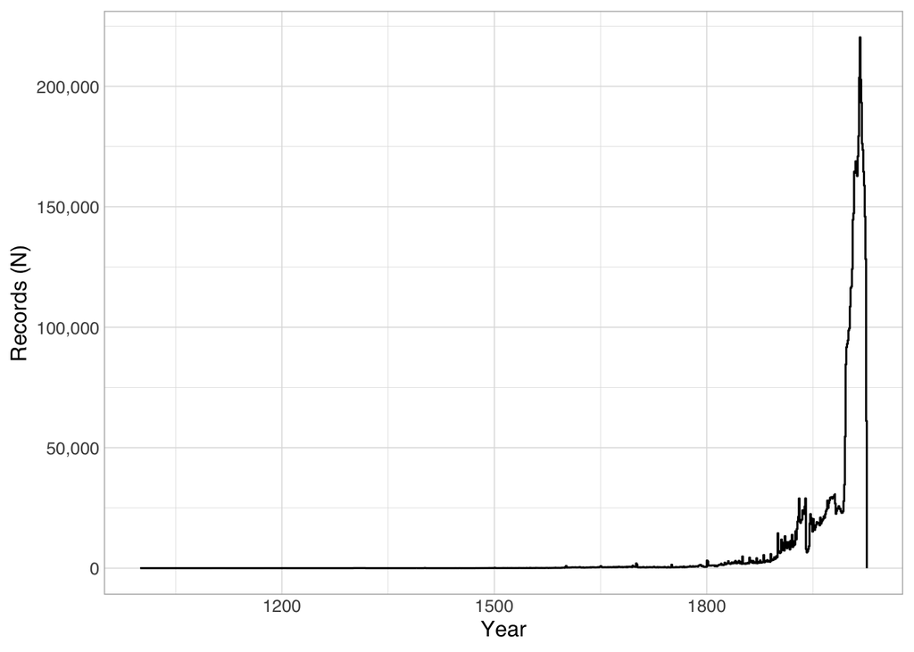

54,806 records do not have easily parseable dates between the years 1000 and 2050.

## Language overview

| [] | Records (N) | Proportion (%) |
| --- | --- | --- |
| pol (Polish) | 4783502 | 0.732827358141244 |
| eng (English) | 610012 | 0.0934531818727067 |
| zxx (No linguistic content; Not applicable) | 283840 | 0.043483982516326 |
| ger (German) | 238000 | 0.0364613438517672 |
| rus (Russian) | 154065 | 0.0236025921870694 |
| fre (French) | 139278 | 0.0213372397016236 |
| lat (Latin) | 56142 | 0.00860089397699963 |
| ita (Italian) | 32344 | 0.00495506598967041 |
| cze (Czech) | 28851 | 0.00441994214902241 |
| ukr (Ukrainian) | 28263 | 0.00432986118185923 |

[output cut: 260 more lines]

# Field code usage overview

In total, 469 distinct fields are used.

Legend for the table below:

- `records`: how many records have at least one of this field
- `r_p`: the above as a percentage of all records
- `n`: the total number of appearances of this field
- `vals_per_rec`: calculated from the above, the mean number of appearances of this field per record
- `recs_with_mult_vals`: the number of records that have more than one repetition of this field

| field_code | field_description | records | r_p | n | vals_per_rec | recs_with_mult_vals |
| --- | --- | --- | --- | --- | --- | --- |
| <a name="001" href="https://www.loc.gov/marc/bibliographic/bd001.html">001</a> | Control Number | 6527448 | 1 | 6527448 | 1 | 0 |
| <a name="005" href="https://www.loc.gov/marc/bibliographic/bd005.html">005</a> | Date and Time of Latest Transaction | 6527448 | 1 | 6527448 | 1 | 0 |
| <a name="006" href="https://www.loc.gov/marc/bibliographic/bd006.html">006</a> | Additional Material Characteristics | 136413 | 0.0208983664059829 | 136533 | 1.00087968155528 | 120 |
| <a name="007" href="https://www.loc.gov/marc/bibliographic/bd007.html">007</a> | Physical Description | 611581 | 0.0936937375832025 | 611691 | 1.0001798617027 | 97 |
| <a name="008" href="https://www.loc.gov/marc/bibliographic/bd008.html">008</a> | General Information | 6527448 | 1 | 6527461 | 1.00000199158998 | 8 |
| <a name="009">009</a> | NA | 6527448 | 1 | 6527448 | 1 | 0 |
| <a name="010" href="https://www.loc.gov/marc/bibliographic/bd010.html">010</a> | Library of Congress Control Number | 52 | 7.9663599005308e-06 | 59 | 1.13461538461538 | 7 |
| <a name="014">014</a> | NA | 3 | 4.59597686569085e-07 | 5 | 1.66666666666667 | 1 |
| <a name="015" href="https://www.loc.gov/marc/bibliographic/bd015.html">015</a> | National Bibliography Number | 3997680 | 0.6124414932145 | 4048682 | 1.01275789958176 | 47744 |
| <a name="016" href="https://www.loc.gov/marc/bibliographic/bd016.html">016</a> | National Bibliographic Agency Control Number | 644 | 9.86603033834969e-05 | 2775 | 4.30900621118012 | 632 |

[output cut: 459 more lines]

# Field code usage overview by subfield

In total, 2,887 distinct field+subfield combinations are used.

Legend for the table below:

- `records`: how many records have at least one of this field+subfield
- `r_p`: the above as a percentage of all records
- `dist_vals`: the number of different values appearing in this field+subfield
- `e_vals`: at most seven random sample values of this field+subfield
- `n`: the total number of appearances of this field+subfield
- `vals_per_rec`: calculated from the above, the mean number of appearances of this field+subfield per record
- `recs_with_mult_vals`: the number of records that have more than one repetition of this field+subfield

| subfield_code | subfield_description | records | r_p | dist_vals | e_vals | n | vals_per_rec | recs_with_mult_vals |
| --- | --- | --- | --- | --- | --- | --- | --- | --- |
| [001: Control Number](https://www.loc.gov/marc/bibliographic/bd001.html) |  |  |  |  |  |  |  |  |
| 001$ | NA | 6,527,448 | 100% | 6,527,448 | b1000002888348 (1)\|b0000006079131 (1)\|b0000002925132 (1)\|b0000003891816 (1)\|b0000004312019 (1)\|b1000000409238 (1)\|b0000002552153 (1) | 6,527,448 | 1 | 0 |
| [005: Date and Time of Latest Transaction](https://www.loc.gov/marc/bibliographic/bd005.html) |  |  |  |  |  |  |  |  |
| 005$ | NA | 6,527,448 | 100% | 1,228 | 20250920065033.6 (2382)\|20250731072618.2 (230)\|20250810065952.5 (1075)\|20250706025331.4 (382)\|20250619055616.5 (284)\|20250925071753.8 (767)\|20250104045603.2 (1952) | 6,527,448 | 1 | 0 |
| [006: Additional Material Characteristics](https://www.loc.gov/marc/bibliographic/bd006.html) |  |  |  |  |  |  |  |  |
| 006$ | NA | 136,413 | 2.09% | 822 | m f d (2)\|g052 vl (1)\|jsgnnb (1)\|sfr p o\|\|\|\|\|0 \|0 (1)\|m q \|m \| (2)\|m cq b (1)\|jppnn (1) | 136,533 | 1 | 120 |
| [007: Physical Description](https://www.loc.gov/marc/bibliographic/bd007.html) |  |  |  |  |  |  |  |  |
| 007$ | NA | 611,581 | 9.37% | 1,740 | co ag nnnuunuu (5)\|vd msaizq (1)\|st uuncmbzcnne (1)\|co agannnuunuu (1)\|sd#bsmdnnmplne (38)\|kh#meo (1)\|sd bmmennmplnu (12) | 611,691 | 1 | 97 |
| [008: General Information](https://www.loc.gov/marc/bibliographic/bd008.html) |  |  |  |  |  |  |  |  |
| 008$ | NA | 6,527,448 | 100% | 2,120,427 | 130205s1962 fr \|000 0 fre (1)\|090623s2009 pl \|000 0 pol (34)\|170419s1783 au \|000 0 pol (1)\|100526s2007 pl 109 \| vlzxx (1)\|080303s1960 xxka \|000 0 eng (1)\|150715s1929 pl ppnn zxx (1)\|080902s… | 6,527,461 | 1 | 8 |
| 009: NA |  |  |  |  |  |  |  |  |
| 009$ | NA | 6,527,448 | 100% | 6,527,113 | 991007830769705066 (1)\|991034148179705066 (1)\|991051327909705066 (1)\|991029557959705066 (1)\|991040774189705066 (1)\|991041145199705066 (1)\|991036000339705066 (1) | 6,527,448 | 1 | 0 |
| [010: Library of Congress Control Number](https://www.loc.gov/marc/bibliographic/bd010.html) |  |  |  |  |  |  |  |  |
| 010$a | LC control number | 52 | 0% | 52 | 2002211427 (1)\|###53036108 (1)\| 2002227223 (1)\| 2005213771 (1)\|##2009235662 (1)\| 2011235753 (1)\| 2009235495 (1) | 52 | 1 | 0 |
| 010$z | Cancelled/invalid LC control number | 7 | 0% | 7 | sn 89022383 (1)\|sn 87012122 (1)\|sn 95030076 (1)\| 2001214082 (1)\| 2009235661 (1)\|sn 86012149 (1)\| 2002227032 (1) | 7 | 1 | 0 |
| 014: NA |  |  |  |  |  |  |  |  |
| 014$Y | NA | 1 | 0% | 1 | 1 (1) | 1 | 1 | 0 |
| 014$a | Linkage number | 3 | 0% | 3 | pol (1)\|UWD 11381 (1)\|PZ 2014 (1) | 3 | 1 | 0 |
| 014$h | NA | 1 | 0% | 1 | ita (1) | 1 | 1 | 0 |
| [015: National Bibliography Number](https://www.loc.gov/marc/bibliographic/bd015.html) |  |  |  |  |  |  |  |  |
| 015$ | NA | 4 | 0% | 4 | BP 116934a (1)\|BL 2020/10/07 (1)\|BP 60459 (1)\|PBB 2019 (1) | 4 | 1 | 0 |
| 015$$ | NA | 1 | 0% | 1 | a LPP 1981-2004/6029 (1) | 1 | 1 | 0 |
| 015$2 | NA | 31 | 0% | 6 | DBN (1)\|doi (21)\|bnb (5)\|dnb (3)\|PBB 2016 (1)\|edtf (1) | 32 | 1.03 | 1 |
| 015$Z | NA | 4 | 0% | 2 | 7 (3)\|0 (1) | 4 | 1 | 0 |
| 015$a | National bibliography number | 3,997,669 | 61.24% | 3,241,722 | PZ 2006/2294 (1)\|BZCz 2016/50414 (1)\|BZCz 2020/44267 (1)\|UWD 1977/2329 (1)\|Prasa 1998/33577 (1)\|UWD 2011/16694 (1)\|PZ 2006/2832 (1) | 4,047,843 | 1.01 | 47,608 |
| 015$b | NA | 75 | 0% | 75 | 000358 (1)\|000368 (1)\|000385 (1)\|000359 (1)\|000388 (1)\|000346 (1)\|000389 (1) | 75 | 1 | 0 |
| 015$c | NA | 2 | 0% | 2 | zł 49,90 (1)\|Kop. 15 (1) | 2 | 1 | 0 |
| 015$n | NA | 668 | 0.01% | 57 | 18 (17)\|01 (10)\|51 (16)\|27 (13)\|36 (7)\|36a (6)\|14 (10) | 672 | 1.01 | 4 |
| 015$q | NA | 2 | 0% | 2 | T. 1 (1)\|(oprawa miękka) : (1) | 2 | 1 | 0 |
| 015$s | NA | 2 | 0% | 2 | BL 2024/05/2024 (1)\|BDD 2021 (1) | 2 | 1 | 0 |

[output cut: 3326 more lines]